# Lab 2

[GitHub Repository](https://github.com/pinoliar/GSB_544_temp)

# 0

```python
import pandas as pd
import numpy as np
import plotnine as p9
```

# 1

```python
df = pd.read_csv("/Users/apinolia/Downloads/GSB_544_temp/Week 3/avocado-updated-2020.csv")
df.head()
df.describe()
df.info()
```

```
<class 'pandas.core.frame.DataFrame'>
RangeIndex: 33045 entries, 0 to 33044
Data columns (total 13 columns):
 #   Column         Non-Null Count  Dtype
---  ------         --------------  -----
 0   date           33045 non-null  object
 1   average_price  33045 non-null  float64
 2   total_volume   33045 non-null  float64
 3   4046           33045 non-null  float64
 4   4225           33045 non-null  float64
 5   4770           33045 non-null  float64
 6   total_bags     33045 non-null  float64
 7   small_bags     33045 non-null  float64
 8   large_bags     33045 non-null  float64
 9   xlarge_bags    33045 non-null  float64
 10  type           33045 non-null  object
 11  year           33045 non-null  int64
 12  geography      33045 non-null  object
dtypes: float64(9), int64(1), object(3)
memory usage: 3.3+ MB
```

The dataset has 33045 observations and 13 variables: date - String values that are the date of the observation average_price - Float values that are the average price of a single avocado total_volume - Float values that are the total number of avocados sold 4046 - Float values that are the total number of avocados with PLU 4046 sold 4225 - Float values that are the total number of avocados with PLU 4225 sold 4770 - Float values that are the total number of avocados with PLU 4770 sold total_bags - Float values are the total number of avocado bags sold small_bags - Float values are the total number of small avocado bags sold large_bags - Float values are the total number of large avocado bags sold xlarge_bags - Float values are the total number of extra large avocado bags sold type - String values that are the type of avocado year - Integer values that are the year of the observation geography - String values that are the city or region of the observation

# 2

```python
df["date"] = pd.to_datetime(df["date"])
df = df[(df["geography"] != "Total U.S.") &
        (df["geography"] != "California") &
        (df["geography"] != "West") &
        (df["geography"] != "Great Lakes") &
        (df["geography"] != "Midsouth") &
        (df["geography"] != "Northeast") &
        (df["geography"] != "Plains") &
        (df["geography"] != "Southeast") &
        (df["geography"] != "South Central")]
west = ["Los Angeles", "San Francisco", "San Diego", "Sacramento", "Seattle",
        "Portland", "Spokane", "Boise", "Phoenix", "Las Vegas", "Reno/Tahoe", "Phoenix/Tucson", "Denver", "West Tex/New Mexico"]
great_lakes = ["Chicago", "Detroit", "Grand Rapids", "Cincinnati/Dayton"]
northeast = ["New York", "Boston", "Philadelphia", "Pittsburgh", "Buffalo/Rochester",
             "Hartford/Springfield", "Albany", "Syracuse", "Harrisburg/Scranton",
             "Northern New England"]
plains = ["Kansas City", "Omaha", "Wichita", "Des Moines"]
southeast = ["Atlanta", "Charlotte", "Jacksonville", "Miami/Ft. Lauderdale",
             "Orlando", "Tampa", "Raleigh/Greensboro", "Richmond/Norfolk", "South Carolina", "Roanoke"]
south_central = ["Dallas/Ft. Worth", "Houston", "San Antonio", "Austin",
                 "Oklahoma City", "Little Rock", "New Orleans/Mobile"]
midsouth = ["Nashville", "Memphis", "Louisville", "Baltimore/Washington",
            "St. Louis", "Indianapolis", "Columbus"]
df.loc[df["geography"].isin(west), "region"] = "West"
df.loc[df["geography"].isin(great_lakes), "region"] = "Great Lakes"
df.loc[df["geography"].isin(northeast), "region"] = "Northeast"
df.loc[df["geography"].isin(plains), "region"] = "Plains"
df.loc[df["geography"].isin(southeast), "region"] = "Southeast"
df.loc[df["geography"].isin(south_central), "region"] = "South Central"
df.loc[df["geography"].isin(midsouth), "region"] = "Midsouth"
df["metro"] = df["geography"]
```

# 3

```python
organic_2017 = df[(df["type"] == "organic") & (df["year"] == 2017)]
organic_2017.groupby("region")["4046"].sum().sort_values(ascending=False)
```

```
region
West             2429564.46
South Central     882659.07
Northeast         851874.19
Southeast         249064.30
Midsouth          171244.60
Great Lakes        56847.16
Name: 4046, dtype: float64
```

West sold the most total organic, small Hass avocados in 2017

# 4

```python
df["M"] = df["date"].dt.month
df["D"] = df["date"].dt.day
df["Y"] = df["date"].dt.year
df.groupby("M")["total_volume"].mean().sort_values(ascending=False)
```

```
M
5     329157.166198
2     320319.598579
6     307525.158808
4     296715.682188
3     290129.055634
1     288404.703679
7     286723.500132
8     278325.173936
9     266688.612132
10    249364.581979
11    242971.370124
12    237493.910176
Name: total_volume, dtype: float64
```

May has the highest average volume of avocado sales

# 5

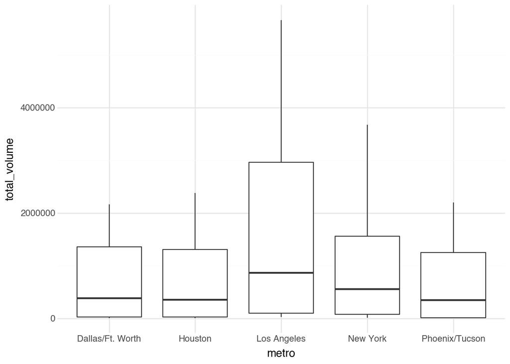

```python
top_5_metro = df.groupby("metro")["total_volume"].mean().sort_values(ascending=False).head(5).index.tolist()
top_5 = df[df["metro"].isin(top_5_metro)]
(p9.ggplot(top_5, p9.aes(x="metro", y="total_volume")) +
        p9.geom_boxplot() +
        p9.theme_minimal()
)
```

Dallas/Ft. Worth, Houston, Los Angeles, New York, and Phoenix/Tucson are the five metro geographical regions with the highest averages for the total_volume variable

# 6

```python
df_california = df[(df["geography"] == "Los Angeles") |
                   (df["geography"] == "Sacramento") |
                   (df["geography"] == "San Diego") |
                   (df["geography"] == "San Francisco")]
```

# 7

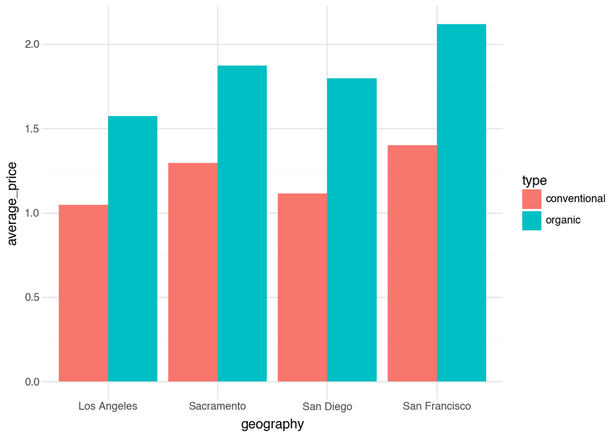

```python
df_california_prices = df_california.groupby(["geography", "type"])["average_price"].mean().reset_index()
df_california_prices_wide = df_california_prices.pivot(index="geography", columns="type", values="average_price")
df_california_prices_wide["price_difference"] = df_california_prices_wide["organic"] - df_california_prices_wide["conventional"]
df_california_prices_wide = df_california_prices_wide.sort_values("price_difference", ascending=False)
df_california_prices_wide["price_difference"].idxmax()
df_california_prices_wide = df_california_prices_wide.reset_index()
df_california_prices_long = df_california_prices_wide.melt(id_vars="geography",
                                                     value_vars=["conventional", "organic"],
                                                     var_name="type",
                                                     value_name="average_price")
(p9.ggplot(df_california_prices_long, p9.aes(x="geography", y="average_price", fill="type")) +
        p9.geom_bar(stat="identity", position="dodge") +
        p9.theme_minimal()
)
```

San Franscisco, is the California regions where the price of organic versus conventional avocados is most different

# 8

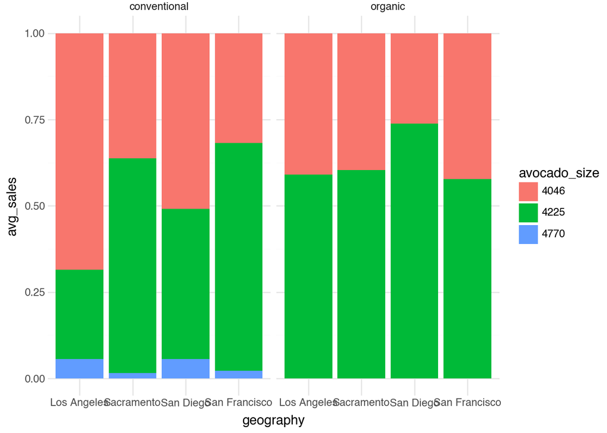

```python
df_california_sales = df_california.groupby(["geography", "type"])[["4046", "4225", "4770"]].mean()
df_california_sales = df_california_sales.reset_index()
df_california_sales_long = df_california_sales.melt(id_vars=["geography", "type"],
                                                     value_vars=["4046", "4225", "4770"],
                                                     var_name="avocado_size",
                                                     value_name="avg_sales")
(p9.ggplot(df_california_sales_long, p9.aes(x="geography", y="avg_sales", fill="avocado_size")) +
        p9.geom_bar(stat="identity", position="fill") +
        p9.facet_wrap("~ type") +
        p9.theme_minimal()
)
```

# Using Outside Data

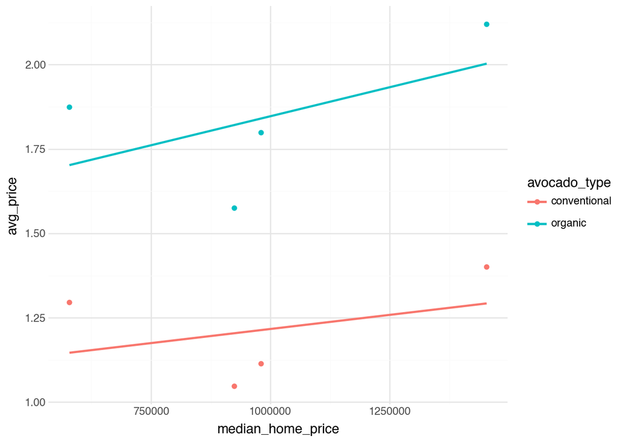

```python
NAR_data = {
    "geography": ["Los Angeles", "Sacramento", "San Diego", "San Francisco"],
    "median_home_price": [924538, 579042, 980533, 1453024]
}
df_housing = pd.DataFrame(NAR_data)
df_california_prices_wide_housing = df_california_prices_wide.merge(df_housing, on="geography")
df_california_prices_wide_housing[["median_home_price", "conventional"]].corr()
df_california_prices_wide_housing[["median_home_price", "organic"]].corr()
df_california_prices_long_housing = df_california_prices_wide_housing.melt(id_vars=["geography","median_home_price"],
                                     value_vars=["conventional", "organic"],
                                     var_name="avocado_type",
                                     value_name="avg_price")
(p9.ggplot(df_california_prices_long_housing, p9.aes(x="median_home_price", y="avg_price", color="avocado_type")) +
        p9.geom_point() +
        p9.geom_smooth(method="lm", se=False) +
        p9.theme_minimal()
)
```

There is a moderate positive relationship between median home price and average price avocado prices